# Introduction to Econometrics: ECON 418-518

Math Review Code

William Brasic The University of Arizona

28 August 2024

# Preliminaries

```r
# Clear environment, plot pane, and console
rm(list = ls())
graphics.off()
cat("\014")
```

```r
# If pacman is not already installed, then install it
if (!require(pacman)) install.packages("pacman")

# Load packages
pacman::p_load(ggplot2, data.table)

# Colors used for plot (https://www.rapidtables.com/web/color/RGB_Color.html)
color_1 <- "#00FF00"
color_2 <- "#ADD8E6"
```

# Linear Function

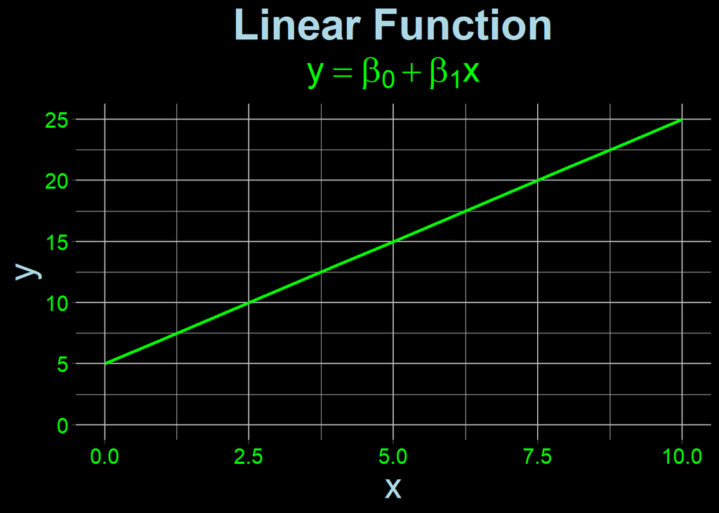

```r
# Define beta_0, beta_1, x, y
beta_0 <- 5
beta_1 <- 2
x <- c(0:10)
y <- beta_0 + (beta_1 * x)

# Put x and y into a data table
dt <- data.table(x, y)

# Create a line plot
ggplot(dt, aes(x, y)) +
  geom_line(linewidth = 1, color = color_1) +
  labs(
    title = "Linear Function",
    subtitle = expression(y == beta[0] + beta[1] * x)
  ) +
  theme(
    panel.background = element_rect(fill = "black", color = "black"),
    plot.background = element_rect(fill = "black", color = "black"),
    panel.grid.major = element_line(color = "gray"),
    panel.grid.minor = element_line(color = "gray"),
    axis.text = element_text(color = color_1, size = 15),
    axis.title = element_text(color = color_2, size = 25),
    plot.title = element_text(hjust = 0.5, color = color_2, size = 30, face = "bold"),
    plot.subtitle = element_text(hjust = 0.5, color = color_1, size = 25)
  ) +
  expand_limits(y = 0) +
  xlab("x") +
  ylab("y")
```

It’s likely you looked at the above code and had no idea what is going on. That’s totally fine! As I said in the R tutorial document which is located on `D2L` under `Content`>`R and RStudio`>`ECON_418-518_R_Tutorial`, when you read some code you can’t understand or need to figure out how to write some code, use `ChatGPT`! I always have `ChatGPT` up when I code and it has increased my coding efficiency ten fold. In fact, I used `ChatGPT` to create that plot!

Please do the following:

1. Go to [ChatGPT](https://chatgpt.com/).
2. If you don’t already have an account, then create one (`ChatGPT 3.5` is currently free). Otherwise, log into your account.
3. On the bottom part of your screen you should see `Message ChatGPT`. In that box, type `What is ggplot2? Also, give me an example of how to use it.` Then, press `Enter`.

You should get a fairly detailed definition of `ggplot2` package as well as an example of how to use it. You can do this for essentially any coding question you may have. Now,

4. Copy and paste the entire block of code from above in the `Message ChatGPT` box. Press the space bar and type `Explain this R code` and press `Enter`.

Again, you should get a fairly detailed description of the code and what each aspect of it does. [Click here](https://chatgpt.com/share/76d724d8-c840-4ae3-9a92-b41302d52757) to see my conversation with `ChatGPT` about `ggplot2` and what the above code does to see for yourself how powerful it is.

I highly encourage you to take advantage of `ChatGPT` throughout this course as well as when you get into the professional world!

# Non-Linear Function

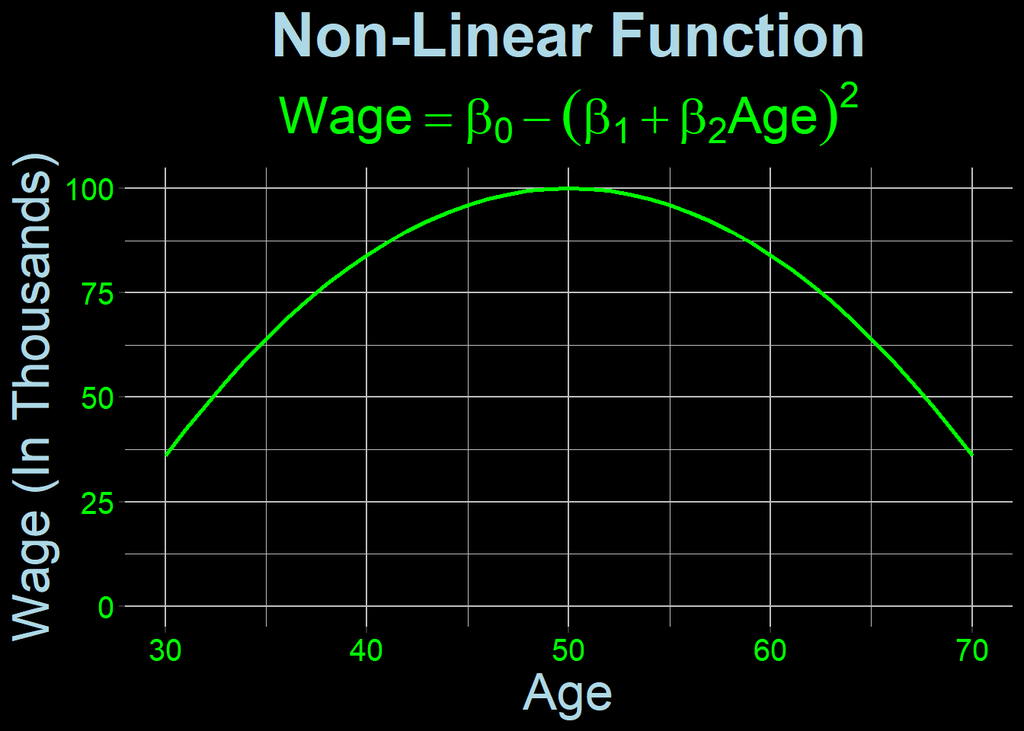

```r
# Define beta_0, beta_1, beta_2, age, wage
beta_0 <- 100
beta_1 <- 20
beta_2 <- 0.4
age <- c(30:70)
wage <- beta_0 - (beta_1 - beta_2 * age)^2

# Put age and wage into a data table
dt <- data.table(age, wage)

# Create a line plot
ggplot(dt, aes(age, wage)) +
  geom_line(linewidth = 1, color = color_1) +
  labs(
    title = "Non-Linear Function",
    subtitle = expression(Wage == beta[0] - (beta[1] + beta[2] * Age)^2)
  ) +
  theme(
    panel.background = element_rect(fill = "black", color = "black"),
    plot.background = element_rect(fill = "black", color = "black"),
    panel.grid.major = element_line(color = "gray"),
    panel.grid.minor = element_line(color = "gray"),
    axis.text = element_text(color = color_1, size = 15),
    axis.title = element_text(color = color_2, size = 25),
    plot.title = element_text(hjust = 0.5, color = color_2, size = 30, face = "bold"),
    plot.subtitle = element_text(hjust = 0.5, color = color_1, size = 25)
  ) +
  expand_limits(y = 0) +
  xlab("Age") +
  ylab("Wage (In Thousands)")
```

# Natural Logarithm Function

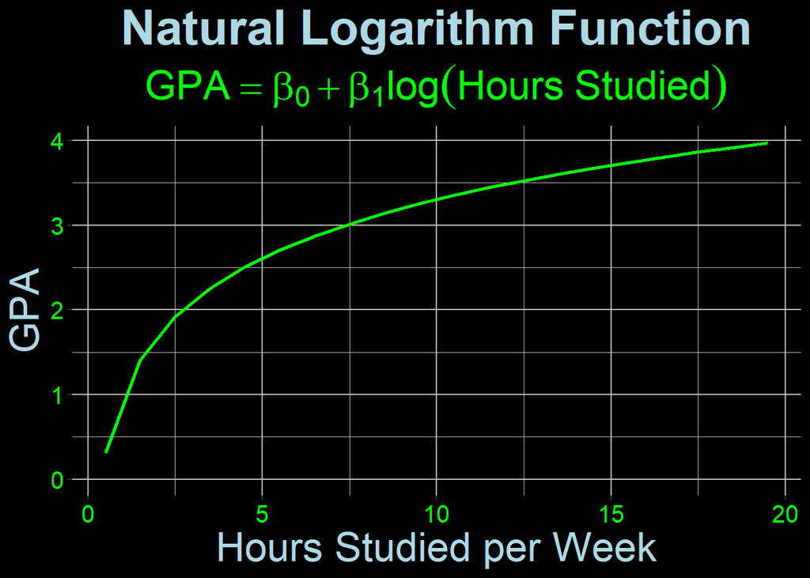

```r
# Define beta_0, beta_1, age, wage
beta_0 <- 0.5
beta_1 <- 0.5
hours_studied <- c(0.5:20)
gpa <- beta_0 + beta_1 + log(hours_studied)

# Put age and wage into a data table
dt <- data.table(hours_studied, gpa)

# Create a line plot
ggplot(dt, aes(hours_studied, gpa)) +
  geom_line(linewidth = 1, color = color_1) +
  labs(
    title = "Natural Logarithm Function",
    subtitle = expression(GPA == beta[0] + beta[1] * log(Hours~Studied))
  ) +
  theme(
    panel.background = element_rect(fill = "black", color = "black"),
    plot.background = element_rect(fill = "black", color = "black"),
    panel.grid.major = element_line(color = "gray"),
    panel.grid.minor = element_line(color = "gray"),
    axis.text = element_text(color = color_1, size = 15),
    axis.title = element_text(color = color_2, size = 25),
    plot.title = element_text(hjust = 0.5, color = color_2, size = 30, face = "bold"),
    plot.subtitle = element_text(hjust = 0.5, color = color_1, size = 25)
  ) +
  expand_limits(y = 0) +
  xlab("Hours Studied per Week") +
  ylab("GPA")
```

# The Normal Distribution

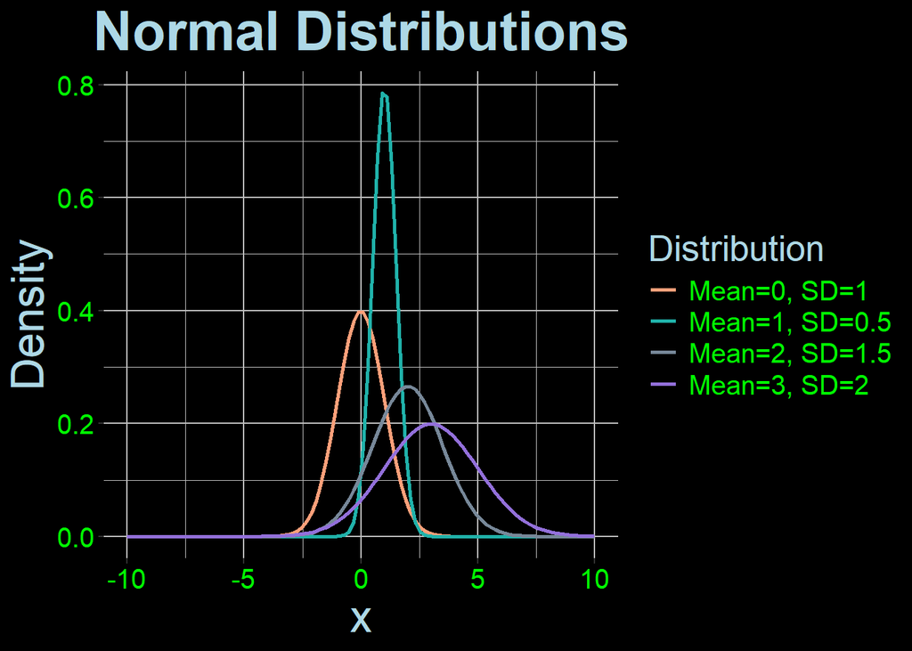

```r
# Create a data table with the normal distributions
means <- c(0, 1, 2, 3)
sds <- c(1, 0.5, 1.5, 2)
x <- seq(-10, 10, length.out = 100)

dt <- data.table(
  x = rep(x, times = 4),
  y = c(dnorm(x, mean = means[1], sd = sds[1]),
        dnorm(x, mean = means[2], sd = sds[2]),
        dnorm(x, mean = means[3], sd = sds[3]),
        dnorm(x, mean = means[4], sd = sds[4])),
  group = factor(rep(1:4, each = 100))
)

# Create the line plot
ggplot(dt, aes(x, y, color = group)) +
  geom_line(linewidth = 1) +
  labs(
    title = "Normal Distributions",
    color = "Distribution"  # Legend title
  ) +
  scale_color_manual(values = c("#FFA07A", "#20B2AA", "#778899", "#9370DB"),
                     labels = c("Mean=0, SD=1", "Mean=1, SD=0.5", "Mean=2, SD=1.5", "Mean=3, SD=2")) +
  theme(
    panel.background = element_rect(fill = "black", color = "black"),
    plot.background = element_rect(fill = "black", color = "black"),
    panel.grid.major = element_line(color = "gray"),
    panel.grid.minor = element_line(color = "gray"),
    axis.text = element_text(color = color_1, size = 15),
    axis.title = element_text(color = color_2, size = 25),
    plot.title = element_text(hjust = 0.5, color = color_2, size = 30, face = "bold"),
    plot.subtitle = element_text(hjust = 0.5, color = color_1, size = 25),
    legend.background = element_rect(fill = "black"),
    legend.text = element_text(color = color_1, size = 15),
    legend.title = element_text(color = color_2, size = 20)
  ) +
  expand_limits(y = 0) +
  xlab("x") +
  ylab("Density")
```